# Homework #1

Nurassilova Omirbanu 1848425

5/14/2019

part 1

A-R algorithm

1. show how it is possible to simulate from a standard Normal distribution using pseudo-randomdeviates from a standard Cauchy and the A-R algorithm
2. provide your R code for the implementation of the A-R

In this task we aimed to simulate normal distribution $f_x$ according to the following:

$f_x(x) \leq k*f_u(x)$ (1)

$f_u(x)$ - in our case it is standard cauchy distribution k - is a constant number

in the next r code we calculated a value for k, and then plotted two distributions:

1. Standard Normal
2. Standard Cauchy * k (we multiplied Standard Cauchy values according to the A-R algorithm)

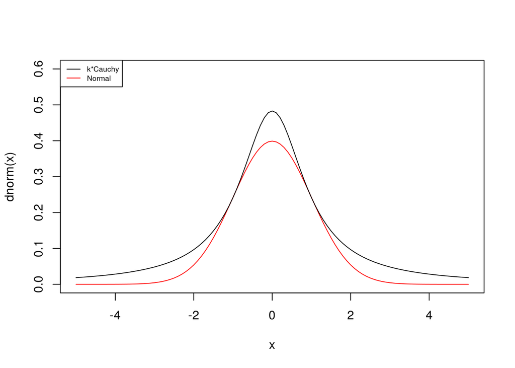

```r
library(lattice)
set.seed(123)
some_val=1
# value of our k
k=(1+some_val^2)/(2.73^((some_val^2)/2))*sqrt(1/(2*3.143))*3.143
curve(dnorm(x), from=-5, to =5,ylim=c(0,0.6),col="red")
curve(k*dcauchy(x),from=-5, to = 5,add=T)
legend("topleft", legend=c("k*Cauchy", "Normal"),
       col=c("black", "red"), lty=1:1, cex=0.6)
```

In order to implement A-R algorithm we need at first take a random value called “u” from uniform distribution and compare it with the following equation:

$\frac{f_x(x)}{k*f_u(x)}$ (2)

if u is less than the equation (2) above we accept the values of x, otherwise we reject x.

In the procedure below M is value of k.

```r
#provide your R code for the implementation of the A-R
accept_or_reject <- function(x_gx, M){
  u=runif(1,0,1)
  if (u<=dnorm(x_gx)/(M*dcauchy(x_gx))){
    return (TRUE)
  }
  else {
    return (FALSE)
  }
}
```

the next step is executing a simulations using our implemented procedure to check variables which were simulated from Standard Cauchy distribution.

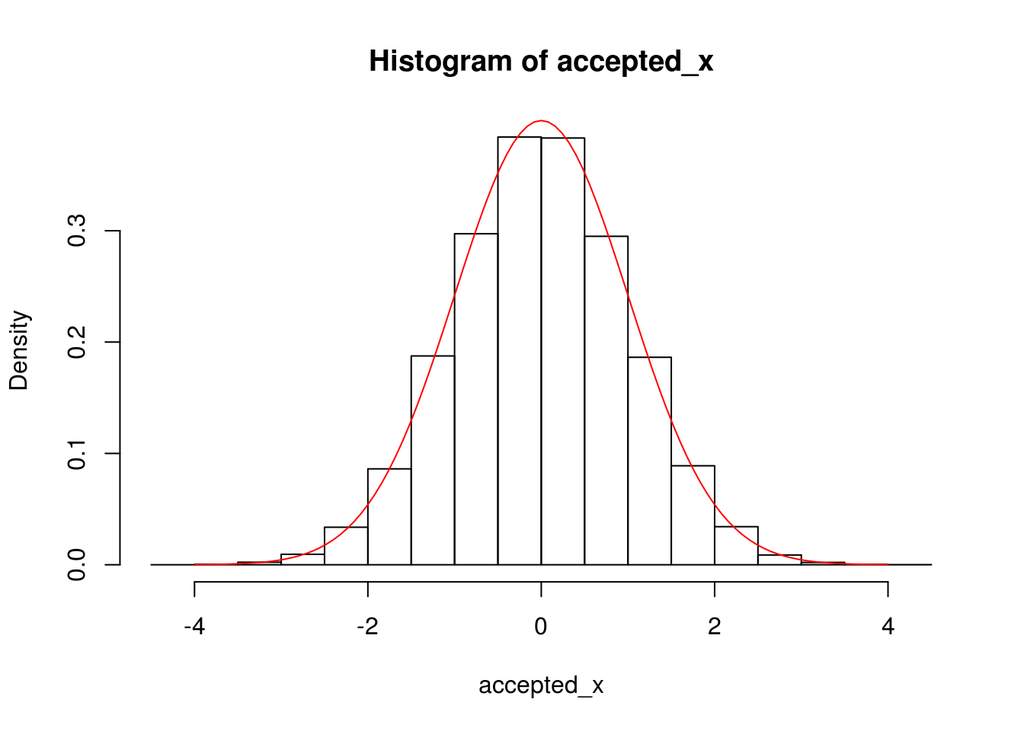

```r
accepted_x<-c()
rejected_x<-c()
Num_of_sim=100000
for (i in 1:Num_of_sim){
  X_gx=rcauchy(1)
  A_R=accept_or_reject(X_gx,k)
  if (A_R==TRUE) {
    accepted_x=c(accepted_x,X_gx)
  }
  if (A_R==FALSE) {
    rejected_x=c(rejected_x,X_gx)
  }
}
hist(accepted_x,freq=FALSE)
curve(dnorm(x), from=-4, to=4, add=T,col="red")
```

Our hist of accepted values is shown above. It shows that our accepted samples fits the standard normal distribution.

3. evaluate numerically (approximately by MC) the acceptance probability

```r
p_mc=length(accepted_x)/Num_of_sim
Theor_p_acc=1/k
cat(" prob of acceptance by simulation:  ",p_mc,'\n',"prob of acceptance according to theory that it is equal 1/k: ", Theor_p_acc)
```

```
##  prob of acceptance by simulation:   0.66056
##  prob of acceptance according to theory that it is equal 1/k:  0.6590132
```

Our theoretical probability is close to that we got by MC simulations.

4. write your theoretical explanation about how you have conceived your Monte Carlo estimate of the acceptance probability

$P(A=1|X=x)= \frac{f_x(x)}{kf_u(x)}=\frac{f_x(x)}{k}$ (3)

Probability of Acceptance depends on joint distribution of X r.v. and A r.v. (acceptance if A=1), so we can write following:

$P(A=1)= \int P(X,A)dx= \int P(A=1|X=x)f_u(x)dx$ (4)

By combaining (3) and (4) we can get the next equation and knowledge that integral of pdf is equal to one:

$P(A=1)= \frac{1}{k}$ (5)

5. save the rejected simulations and provide a graphical representation of the empirical distribution(histogram or density estimation)

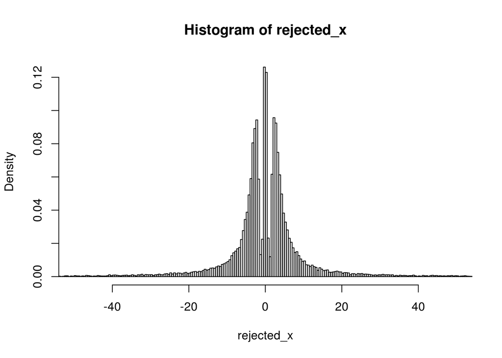

```r
hist(rejected_x,freq=FALSE,breaks=100000,xlim = c(-50,50))
```

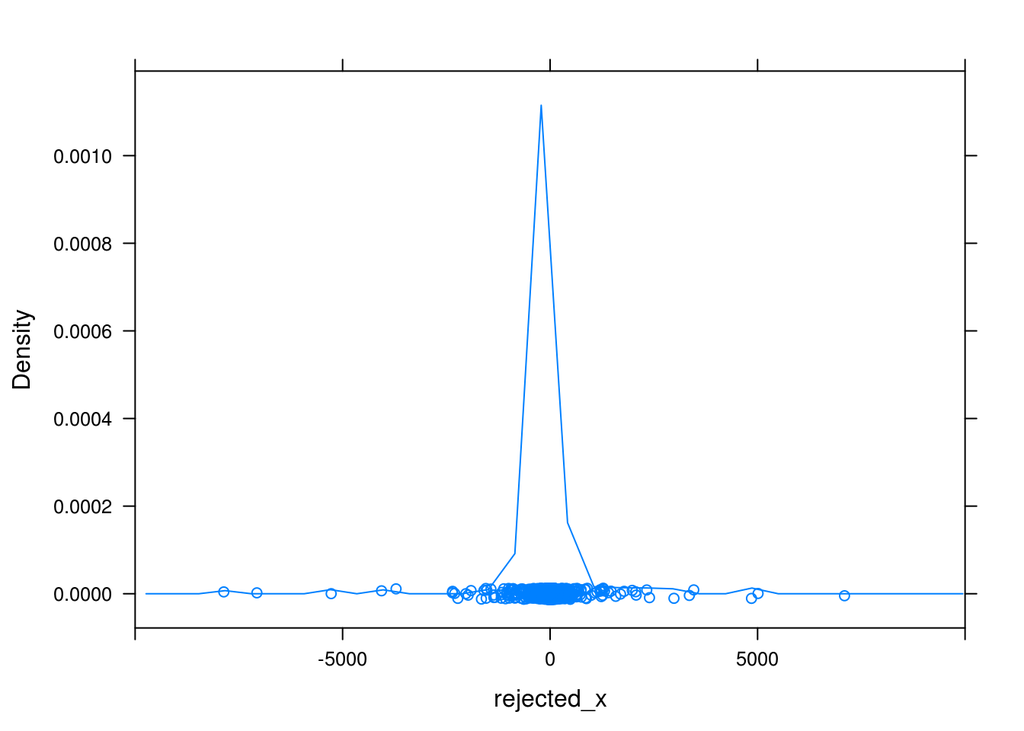

```r
densityplot(rejected_x, xlim=c(-10000,10000), bins=2)
```

6. derive the underlying density corresponding to the rejected random variables and try to compare it with the empirical distribution

For rejected values we have distribution that is close to k*Cauchy-Normal:

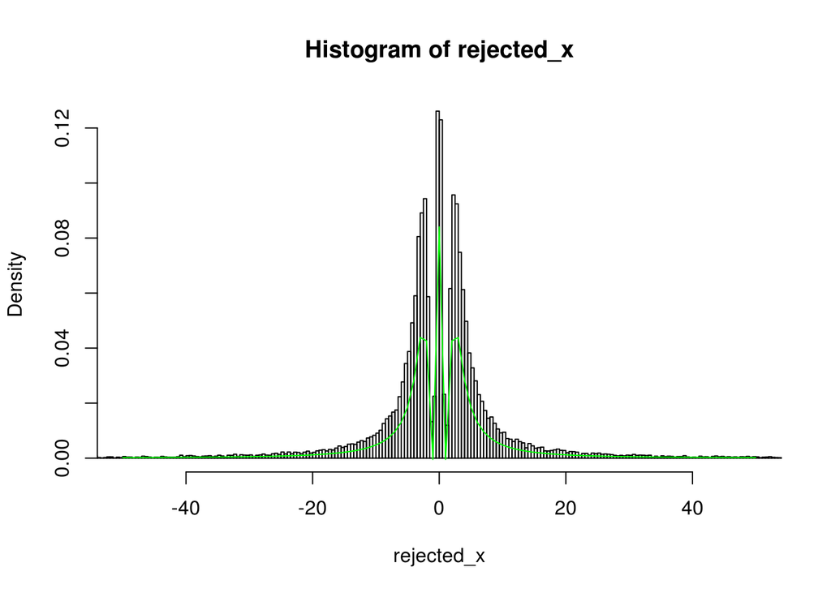

```r
hist(rejected_x,freq=FALSE,breaks=100000,xlim = c(-50,50))
curve(dcauchy(x)*k-dnorm(x), from =-50, to=50, col="green", add=T)
```

part 2

2. Marginal likelihood evaluation for a Poisson data model. Simulate 10 observations from a knownPoisson distribution with expected value 2. Useset.seed(123)before starting your simulation. Use aGamma(1,1) prior distribution and compute the corresponding marginal likelihood in 3 differnt ways:
1. exact analytic computation

we have n iid random variables y1,…,yn from Poisson distribution as the samle data. Let us wirte their joint pdf:

$P(Y_1=y_1,Y_2=y_2,...,Y_n=y_n|\theta)=\prod_{i=1}^{n}\frac{1}{y_i!}\theta^y_ie^-\theta=\theta^{\sum y_i} e^{-n\theta} \prod_{i=1}^{n}\frac{1}{y_i!}$ (6)

$\pi (\theta) = \frac{\beta^\alpha}{\Gamma(\alpha)} \theta^{\alpha-1}e^{-\beta\theta}$ (7)

We can compute posterior now:

$P(\theta|y_1,...,y_n) = \frac{\beta^\alpha}{\Gamma(\alpha)} \theta^{\alpha-1}e^{-\beta\theta}\theta^{\sum y_i}e^{-n\theta} \prod_{i=1}^{n}\frac{1}{y_i!}$ (8)

$P(\theta|y_1,...,y_n) = \frac{\beta^\alpha}{\Gamma(\alpha)} \theta^{\alpha-1+\sum y_i}e^{-{(\beta+n)}\theta}\prod_{i=1}^{n}\frac{1}{y_i!}$ (9)

our posterior distribution of theta is the gamma distribution with alpha_post = alpha + sum(our data), beta_post=beta+n

$\theta|y_1,...,y_n \sim gamma(\alpha + \sum{y_i}; \beta + n)$

our marginal likelihood is following:

$b(data|m)=\int f(data|\theta, m)\pi(\theta|m)d\theta= \int L(\theta)\pi(\theta)d\theta$ (10)

$b(data|m)=\int \frac{\beta^\alpha}{\Gamma(\alpha)} \theta^{\alpha-1+\sum y_i}e^{-{(\beta+n)}\theta}\prod_{i=1}^{n}\frac{1}{y_i!} d\theta$ (11)

$b(data|m)= \frac{\beta^\alpha}{\Gamma(\alpha)} \frac{\Gamma(\alpha+\sum y+i)}{(\beta + n)^{\alpha+\sum y_i}} \prod_{i=1}^{n}\frac{1}{y_i!}$ (12)

Finally, we can compute the integral using r:

```r
set.seed(123)
n<-10 # given number of observation
mu=2 # given lambda
# taking observations from Poisson distribution with expected value 2
our_obs=rpois(n=10,mu)
#sum(our_obs)
# getting a likelihood value with given data and lambda
L_pois<- function(lambda_value){
  prod(dpois(our_obs,lambda=lambda_value))
}
L1_vec <- Vectorize(L_pois)
# parameters of gamma distribution alpha and beta
a=1 #alpha
b=1 #beta
value_of_marginal <- function(aa,bb,x_obs,nn){
  ((bb^aa)*prod(1/factorial(x_obs))*gamma(aa+sum(x_obs))/(gamma(aa)*((bb+nn)^(aa+sum(x_obs)))))
  }
value_of_marg<- value_of_marginal(a,b,our_obs,n)
value_of_marg
```

```
## [1] 4.315028e-09
```

2. by Monte Carlo approximation using a sample form the posterior distribution and the harmonic mean approach. Try to evaluate random behaviour by repeating/iterating the approximation I_hat a sufficiently large number of times and show that the approximation tends to be (positively) biased.Use these simulations to evaluate approximately the corresponding variance and mean square error:

our posterior is:

$\theta|y_1,...,y_n \sim gamma(\alpha + \sum y_i; \beta + n)$

Harmonic mean approach:

$\epsilon^{HM}=\frac{1}{{\frac{1}{t}}\sum_{i=1}^{t}{\frac{1}{L(\theta_i)}}}$ (12)

to evaluate this task we need to repeat following steps procedure 10000 times:

1. we got 1000 samples from posterior distribution
2. calculated the likelihood values for that thetas
3. save the calculation according to a formula above

then we can compute bias and MSE

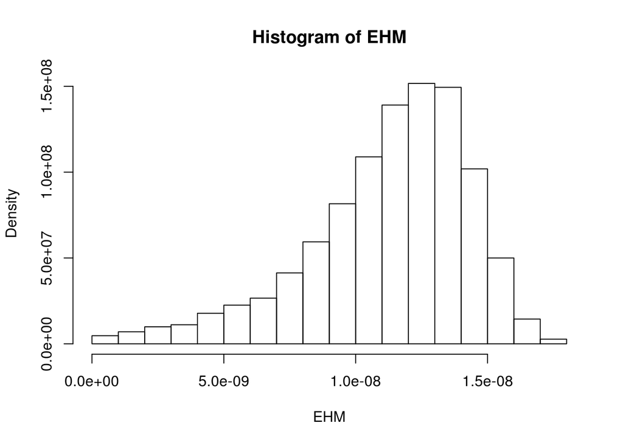

```r
num_of_samples=10000
a_post=a+sum(our_obs)
b_post=b+n
EHM=c()
# harmonic mean # part 2.2
for (u in 1:num_of_samples){
  theta_posterior <- rgamma(1000,a_post,b_post)
  L_val<- L1_vec(theta_posterior)
  EHM<- c(EHM,1/(sum(1/L_val)/1000))
}
hist(EHM,freq=FALSE)
```

```r
# bias
bias_of_est<- mean(EHM) - value_of_marg
#var
var_of_est<- var(EHM)
# MSE
MSE<- bias_of_est^2+ var_of_est
cat("bias: ",bias_of_est, "\n","var: ",var_of_est, "\n",'MSE: ',MSE, "\n")
```

```
## bias:  6.920568e-09
##  var:  9.554417e-18
##  MSE:  5.744868e-17
```

```r
# theta
cat("bias_theta: ",mean(theta_posterior)-mu, "\n","var_theta: ",var(theta_posterior), "\n","MSE_theta: ",(mean(theta_posterior)-mu)^2 +var(theta_posterior) , "\n")
```

```
## bias_theta:  0.2618957
##  var_theta:  0.2037046
##  MSE_theta:  0.272294
```

From the results we see that bias is positive number.

3. by Monte Carlo Importance sampling choosing an appropriate Cauchy distribution as auxiliary distribution for the simulation. Compare its performance with respect to the previous harmonic mean approach

In importance sampling we use following:

Our theta value will be distributed from Cauchy distribution:

$\theta_1,...,\theta_t \sim Cauchy(0, 1)$

$\hat{I}=\frac{1}{t}\sum_{1}^{t}h(\theta_i)\frac{\pi(\theta_i)}{q(\theta_i)}$ (13)

in (13) formula the h(theta) is our likelihood, pi(theta) is our prior, and q(theta is our auxiliary distribution, which is now Cauchy distribution)

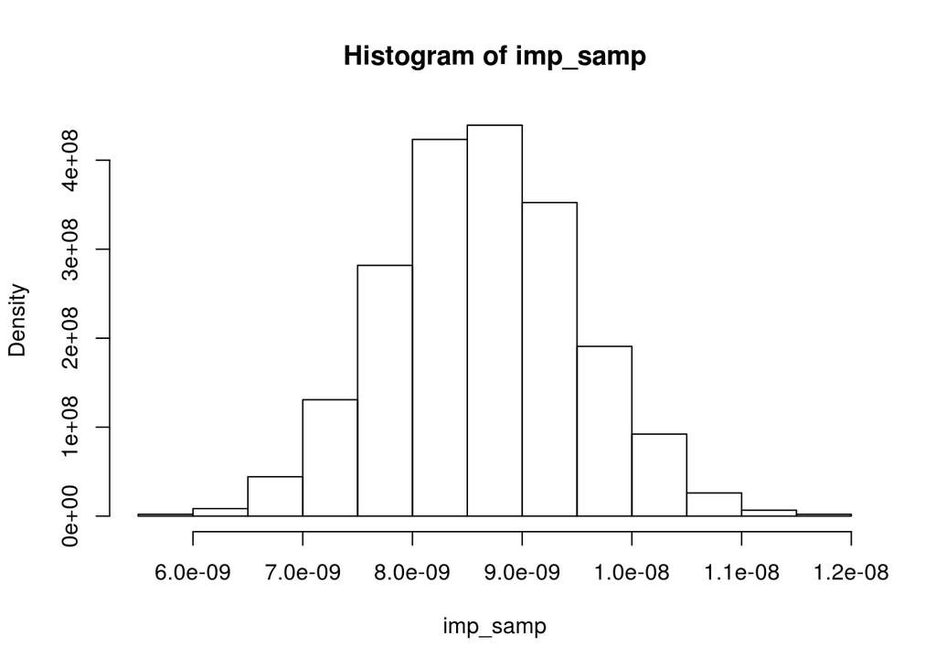

```r
num_of_samples=10000
a_post=a+sum(our_obs)
b_post=b+n
imp_samp=c()

for (u in 1:num_of_samples){
  theta_posterior <- rcauchy(1000)#rgamma(1000,a_post,b_post)#
  theta_posterior<-theta_posterior[theta_posterior>0]
  L_val<- mean((L1_vec(theta_posterior)*dgamma(theta_posterior,1,1))/(dcauchy(theta_posterior)))
  imp_samp<- c(imp_samp,L_val)
}
hist(imp_samp,freq=FALSE)
```

```r
# bias
bias_of_est2<- mean(imp_samp) - value_of_marg
#var
var_of_est2<- var(imp_samp)
# MSE
MSE2<- bias_of_est2^2+ var_of_est2
cat("bias ",bias_of_est2,"\n","var ",var_of_est2,"\n","MSE",MSE2,"\n")
```

```
## bias  4.323363e-09
##  var  7.539441e-19
##  MSE 1.944541e-17
```

```r
#theta
cat("bias_theta: ",mean(theta_posterior)-mu, "\n","var_theta: ",var(theta_posterior), "\n","MSE_theta: ",(mean(theta_posterior)-mu)^2 +var(theta_posterior) , "\n")
```

```
## bias_theta:  1.664529
##  var_theta:  183.656
##  MSE_theta:  186.4267
```

If we compare the results of two different approaches the harmonic mean is not better that importance sampling. We can say that because of values of MSE for two methods. Harmonic mean has more MSE that importance sampling.

```r
cat("HM_MSE: ",MSE,"  IS_MSE: ",MSE2,"\n")
```

```
## HM_MSE:  5.744868e-17   IS_MSE:  1.944541e-17
```

```r
MSE<MSE2
```

```
## [1] FALSE
```